# Discussion - Week12

David Simbandumwe

```
## ResourceSelection 0.3-5   2019-07-22
```

[output not shown]

# Week 12 - Assignment

Using R, build a multiple regression model for data that interests you. Include in this model at least one quadratic term, one dichotomous term, and one dichotomous vs. quantitative interaction term. Interpret all coefficients. Conduct residual analysis. Was the linear model appropriate? Why or why not?

Notes: - one quadratic term - one dichotomous term - and one dichotomous vs. quantitative interaction term

Questions: - Interpret all coefficients. - Conduct residual analysis - Was the linear model appropriate?

# Medical insurance costs

This dataset was inspired by the book Machine Learning with R by Brett Lantz. The data contains medical information and costs billed by health insurance companies. It contains 1338 rows of data and the following columns: age, gender, BMI, children, smoker, region and insurance charges.

Columns

- age: age of primary beneficiary
- sex: insurance contractor gender, female, male
- bmi: Body mass index, providing an understanding of body, weights that are relatively high or low relative to height, objective index of body weight (kg / m ^ 2) using the ratio of height to weight, ideally 18.5 to 24.9
- children: Number of children covered by health insurance / Number of dependents
- smoker: Smoking
- region: the beneficiary’s residential area in the US, northeast, southeast, southwest, northwest.
- charges: Individual medical costs billed by health insurance
- H0 - The medical information captured in the insurance dataset does not predict the level of charges for individuals. age, sex, bmi, children, smoker, and region are not predictors of medical charges.
- H1 - The medical information captured in the insurance dataset does predict the level of charges for individuals. age, sex, bmi, children, smoker, and region are predictors of medical charges.

```r
destfile <- tempfile()
download.file("https://gist.githubusercontent.com/meperezcuello/82a9f1c1c473d6585e750ad2e3c05a41/raw/d42d226d0dd64e7f5395a0eec1b9190a10edbc03/Medical_Cost.csv", destfile)
df <-  read_csv(destfile, col_types = list('region' = col_factor(), 'children' = col_factor()))
```

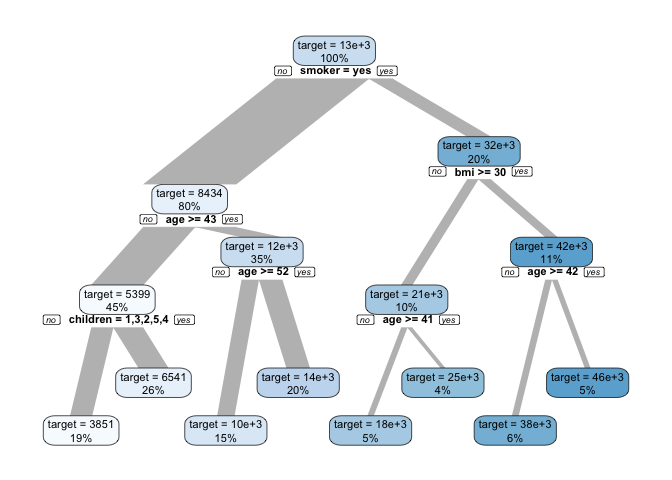

```r
df %>% explain_tree(target = charges)
```

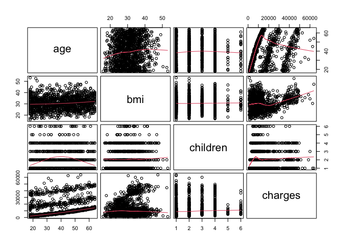

```r
df %>% select(age,bmi,children,charges) %>% pairs(panel = panel.smooth, gap=0.5)
```

```r
summary(df)
```

```
##       age            sex                 bmi        children    smoker
##  Min.   :18.00   Length:1338        Min.   :15.96   0:574    Length:1338
##  1st Qu.:27.00   Class :character   1st Qu.:26.30   1:324    Class :character
##  Median :39.00   Mode  :character   Median :30.40   3:157    Mode  :character
##  Mean   :39.21                      Mean   :30.66   2:240
##  3rd Qu.:51.00                      3rd Qu.:34.69   5: 18
##  Max.   :64.00                      Max.   :53.13   4: 25
##        region       charges
##  southwest:325   Min.   : 1122
##  southeast:364   1st Qu.: 4740
##  northwest:325   Median : 9382
##  northeast:324   Mean   :13270
##                  3rd Qu.:16640
##                  Max.   :63770
```

- The explain tree identifies smoking and age seem to bprimary predictors of medical charges
- The pairs graph shows unclear relationships between medical charges and number of children.

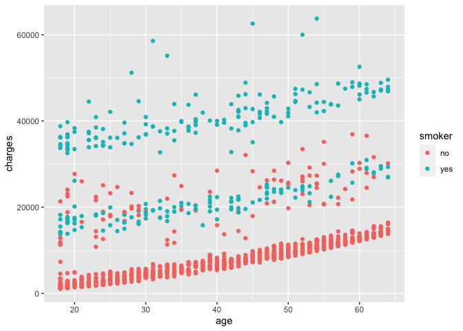

```r
ggplot(df, aes(x=age, y=charges, color=smoker)) + geom_point()
```

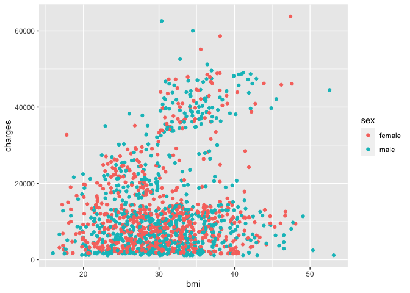

```r
ggplot(df, aes(x=bmi, y=charges, color=sex)) + geom_point()
```

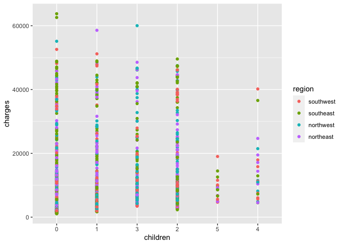

```r
ggplot(df, aes(x=children, y=charges, color=region)) + geom_point()
```

- The graph of age vs medical charges colored by the smoking cateogry shows an interesting relationship between these three variables
- It appears that individual fall into 3 broad categories when compairing medical charges to age. The lowest band is for no smokers the highest band is for smokers and then there is a middle band that includes a mix.

```r
df_lm.full <- lm(data = df, charges ~ .)
summary(df_lm.full)
```

```
##
## Call:
## lm(formula = charges ~ ., data = df)
##
## Residuals:
##      Min       1Q   Median       3Q      Max
## -11689.4  -2902.6   -943.7   1492.2  30042.7
##
## Coefficients:
##                  Estimate Std. Error t value Pr(>|t|)
## (Intercept)     -12880.06    1027.62 -12.534  < 2e-16 ***
## age                257.19      11.91  21.587  < 2e-16 ***
## sexmale           -128.16     332.83  -0.385 0.700254
## bmi                336.91      28.61  11.775  < 2e-16 ***
## children1          390.98     421.35   0.928 0.353619
## children3          964.34     548.10   1.759 0.078735 .
## children2         1635.78     466.67   3.505 0.000471 ***
## children5         1116.04    1456.02   0.767 0.443514
## children4         2947.37    1239.16   2.379 0.017524 *
## smokeryes        23836.41     414.14  57.557  < 2e-16 ***
## regionsoutheast    -80.25     470.56  -0.171 0.864611
## regionnorthwest    572.84     478.44   1.197 0.231395
## regionnortheast    952.89     478.15   1.993 0.046483 *
## ---
## Signif. codes:  0 '***' 0.001 '**' 0.01 '*' 0.05 '.' 0.1 ' ' 1
##
## Residual standard error: 6059 on 1325 degrees of freedom
## Multiple R-squared:  0.7519, Adjusted R-squared:  0.7497
## F-statistic: 334.7 on 12 and 1325 DF,  p-value: < 2.2e-16
```

The linear regression model has p-value of less 0.05 so we reject the Null hypothesis in favor of the alternate hypothesis. The full model with an adjusted R squared of 0.7497 shows strong explanatory power. Surprisingly sex does not appear to be a significant predictor of medical costs.

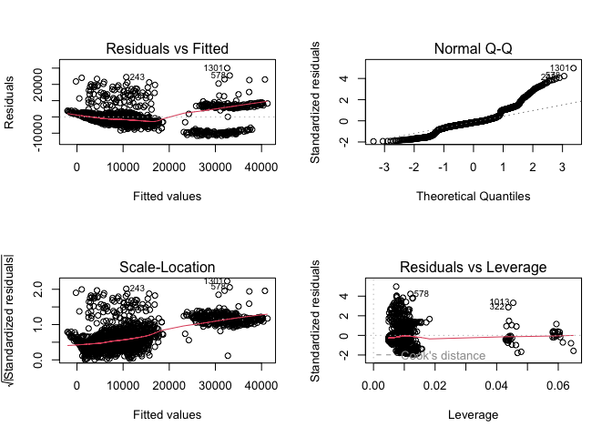

```r
par(mfrow=c(2,2))
plot(df_lm.full)
```

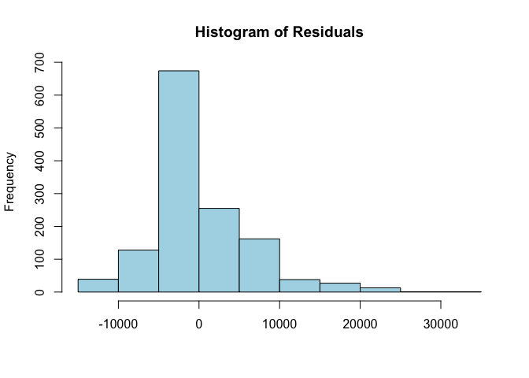

```r
hist(df_lm.full$residuals, main = "Histogram of Residuals", xlab= "", col= "lightblue")
```

- Normal Q-Q - we see a deviation from the guide indicating that the residuals do not follow a normal distribution
- Residual Historgram - the residual histogram is close to normally distributed but skews right slightly

```r
df$bmi2 <- sqrt(df$bmi)
df$age2 <- df$age^2

df_lm.1 <- lm(data = df, charges ~ age2 + bmi2 + smoker )
summary.lm(df_lm.1, correlation=TRUE)
```

```
##
## Call:
## lm(formula = charges ~ age2 + bmi2 + smoker, data = df)
##
## Residuals:
##      Min       1Q   Median       3Q      Max
## -11480.2  -3044.5   -986.6   1539.2  29415.9
##
## Coefficients:
##               Estimate Std. Error t value Pr(>|t|)
## (Intercept) -1.692e+04  1.670e+03  -10.13   <2e-16 ***
## age2         3.256e+00  1.486e-01   21.91   <2e-16 ***
## bmi2         3.568e+03  3.030e+02   11.77   <2e-16 ***
## smokeryes    2.384e+04  4.115e+02   57.94   <2e-16 ***
## ---
## Signif. codes:  0 '***' 0.001 '**' 0.01 '*' 0.05 '.' 0.1 ' ' 1
##
## Residual standard error: 6072 on 1334 degrees of freedom
## Multiple R-squared:  0.7492, Adjusted R-squared:  0.7486
## F-statistic:  1328 on 3 and 1334 DF,  p-value: < 2.2e-16
##
## Correlation of Coefficients:
##           (Intercept) age2  bmi2
## age2      -0.04
## bmi2      -0.98       -0.12
## smokeryes -0.05        0.03 -0.01
```

- intercept = -1.692e+04
- age coefficient = 3.256e+00
- bmi coefficient = 3.568e+03
- smoker indicator = 2.384e+04

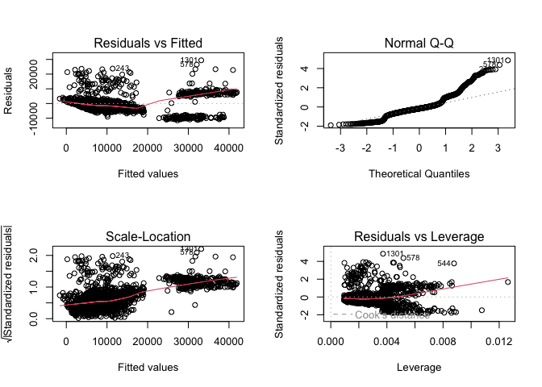

```r
par(mfrow=c(2,2))
plot(df_lm.1)
```

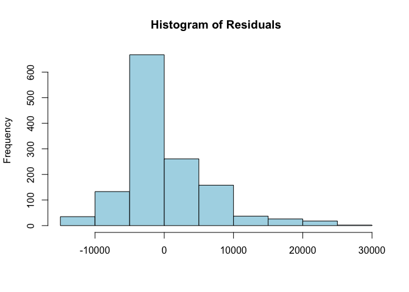

```r
hist(df_lm.1$residuals, main = "Histogram of Residuals", xlab= "", col= "lightblue")
```

- Normal Q-Q - we see a deviation from the guide indicating that the residuals do not follow a normal distribution
- Residual Historgram - the residual histogram is close to normally distributed but skews right slightly

```r
VIF(df_lm.1)
```

```
##     age2     bmi2   smoker
## 1.014417 1.013729 1.000709
```

All variables have a Variance Inflation Factor of close to 1 indicating low correlation between the given predictors.

# Conclusion

The second model has a very similar adjusted r-squared to the full model but includes fewer variables. The model includes 3 significant predictors age, bmi and smoking indicator.

# Other analysis

## stepwise regression

```r
full.model <- lm(charges ~., data = df)
step.model <- stepAIC(full.model, direction = "both",
                      trace = FALSE)
summary(step.model)
```

```
##
## Call:
## lm(formula = charges ~ children + smoker + region + bmi2 + age2,
##     data = df)
##
## Residuals:
##    Min     1Q Median     3Q    Max
## -11707  -2907  -1029   1585  30645
##
## Coefficients:
##                   Estimate Std. Error t value Pr(>|t|)
## (Intercept)     -1.883e+04  1.757e+03 -10.722  < 2e-16 ***
## children1        7.980e+02  4.181e+02   1.908  0.05655 .
## children3        1.342e+03  5.432e+02   2.470  0.01364 *
## children2        2.099e+03  4.632e+02   4.532 6.38e-06 ***
## children5        1.654e+03  1.446e+03   1.144  0.25273
## children4        3.316e+03  1.230e+03   2.695  0.00712 **
## smokeryes        2.384e+04  4.099e+02  58.157  < 2e-16 ***
## regionsoutheast -6.251e+01  4.666e+02  -0.134  0.89346
## regionnorthwest  5.512e+02  4.749e+02   1.161  0.24596
## regionnortheast  9.749e+02  4.748e+02   2.053  0.04024 *
## bmi2             3.704e+03  3.134e+02  11.819  < 2e-16 ***
## age2             3.257e+00  1.476e-01  22.073  < 2e-16 ***
## ---
## Signif. codes:  0 '***' 0.001 '**' 0.01 '*' 0.05 '.' 0.1 ' ' 1
##
## Residual standard error: 6015 on 1326 degrees of freedom
## Multiple R-squared:  0.7554, Adjusted R-squared:  0.7533
## F-statistic: 372.2 on 11 and 1326 DF,  p-value: < 2.2e-16
```

## Ridge Regression

```r
#define response variable
y <- df$charges

#define matrix of predictor variables
x <- data.matrix(df[, c('age', 'sex', 'bmi','smoker')])

#fit ridge regression model
model <- glmnet(x, y, alpha = 0)

#view summary of model
summary(model)
```

```
##           Length Class     Mode
## a0        100    -none-    numeric
## beta      400    dgCMatrix S4
## df        100    -none-    numeric
## dim         2    -none-    numeric
## lambda    100    -none-    numeric
## dev.ratio 100    -none-    numeric
## nulldev     1    -none-    numeric
## npasses     1    -none-    numeric
## jerr        1    -none-    numeric
## offset      1    -none-    logical
## call        4    -none-    call
## nobs        1    -none-    numeric
```

```r
#perform k-fold cross-validation to find optimal lambda value
cv_model <- cv.glmnet(x, y, alpha = 0)

#find optimal lambda value that minimizes test MSE
best_lambda <- cv_model$lambda.min
best_lambda
```

```
## [1] 953.006
```

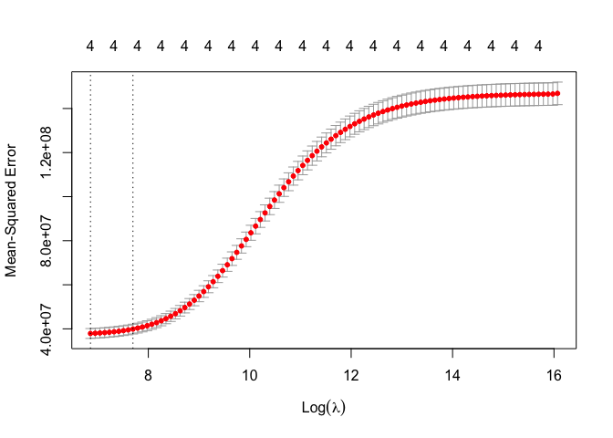

```r
#produce plot of test MSE by lambda value
plot(cv_model)
```

```r
#find coefficients of best model
best_model <- glmnet(x, y, alpha = 0, lambda = best_lambda)
coef(best_model)
```

```
## 5 x 1 sparse Matrix of class "dgCMatrix"
##                        s0
## (Intercept) -3.205907e+04
## age          2.402561e+02
## sex         -9.973888e-01
## bmi          3.039801e+02
## smoker       2.207053e+04
```

## Other Analysis

```r
unique(df$region)
```

```
## [1] southwest southeast northwest northeast
## Levels: southwest southeast northwest northeast
```

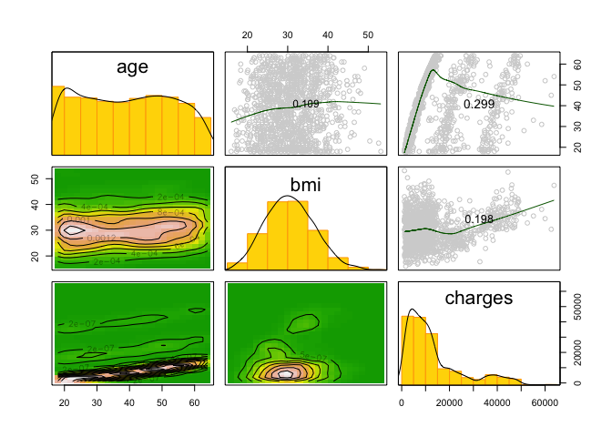

```r
df0 <- df %>% dplyr::select(age, bmi, charges)
df_r1 <- df %>% filter(df$region == 'southwest') %>% dplyr::select(age, bmi, charges)
df_r2 <- df %>% filter(df$region == 'southeast') %>% dplyr::select(age, bmi, charges)
df_r3 <- df %>% filter(df$region == 'northwest') %>% dplyr::select(age, bmi, charges)
df_r4 <- df %>% filter(df$region == 'northeast') %>% dplyr::select(age, bmi, charges)

kdepairs(df0)
```

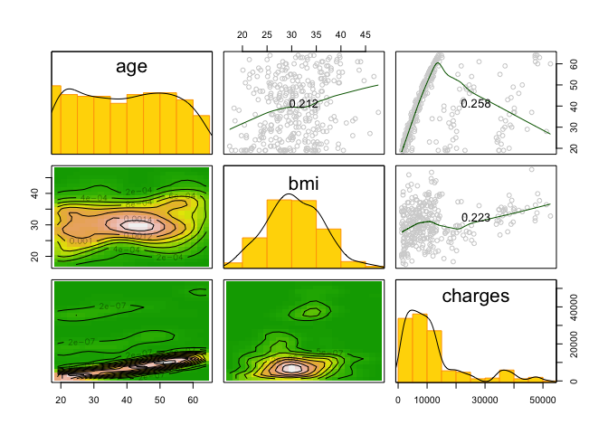

```r
kdepairs(df_r1)
```

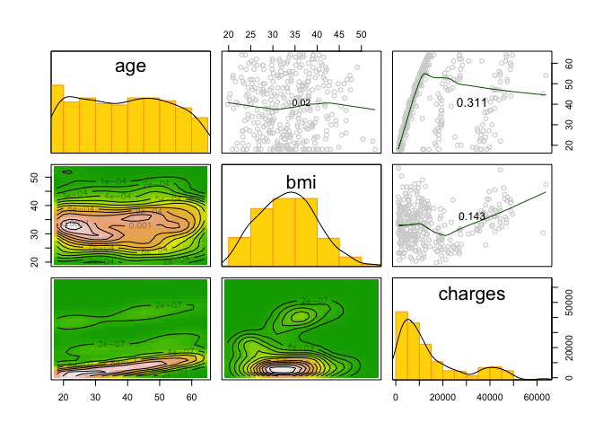

```r
kdepairs(df_r2)
```

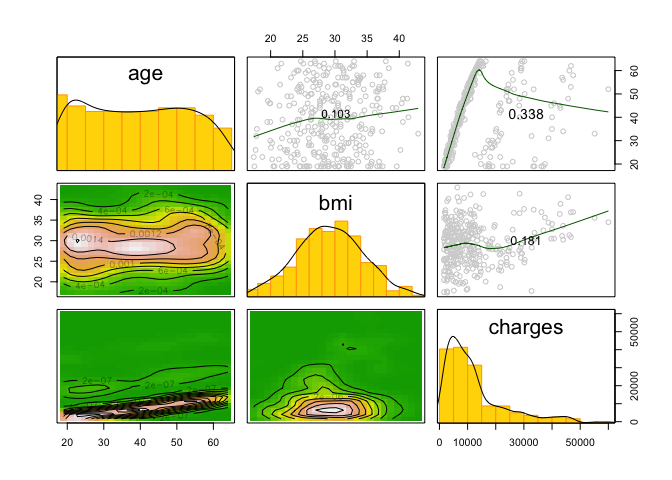

```r
kdepairs(df_r3)
```

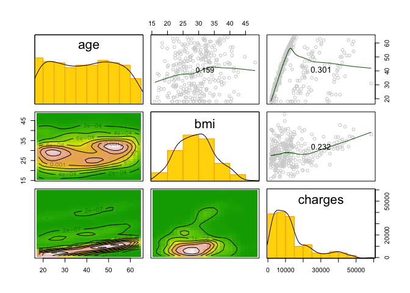

```r
kdepairs(df_r4)
```

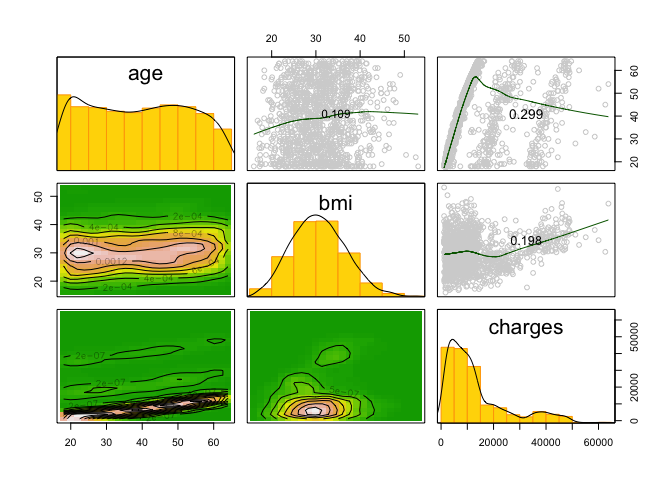

```r
df_s1 <- df %>% filter(df$smoker == 'no') %>% dplyr::select(age, bmi, charges)
df_s2 <- df %>% filter(df$smoker == 'yes') %>% dplyr::select(age, bmi, charges)

kdepairs(df0)
```

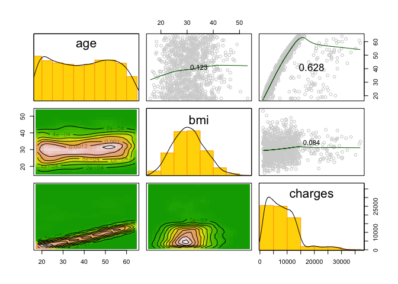

```r
kdepairs(df_s1)
```

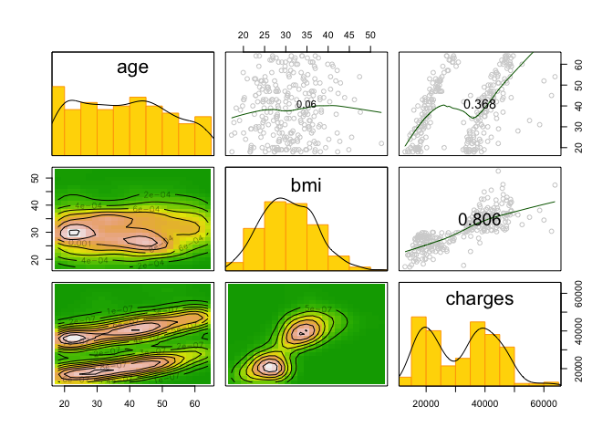

```r
kdepairs(df_s2)
```